# Plaque expression levels of *HDAC9* in association with plaque vulnerability traits and secondary vascular events in patients undergoing carotid endarterectomy: an analysis in the Athero-EXPRESS Biobank.

Athero-Express Biobank Study baseline characteristics

[Sander W. van der Laan, PhD](https://swvanderlaan.github.io) | @swvanderlaan | s.w.vanderlaan@gmail.com

2022-03-18

# General Setup

```
Create a new analysis directory...
[1] FALSE
[1] FALSE
[1] FALSE
[1] FALSE
[1] FALSE
[1] "/Users/swvanderlaan/git/CirculatoryHealth/AE_20211201_YAW_SWVANDERLAAN_HDAC9"
 [1] "1. AE_20211201_YAW_SWVANDERLAAN_HDAC9.nb.html" "1. AE_20211201_YAW_SWVANDERLAAN_HDAC9.Rmd"
 [3] "2. SNP_analyses.Rmd"                           "20220317.HDAC9.baseline.RData"
 [5] "3. bulkRNAseq.Rmd"                             "AE_20211201_YAW_SWVANDERLAAN_HDAC9.Rproj"
 [7] "AnalysisPlan"                                  "bulkRNAseq"
 [9] "HDAC9"                                         "images"
[11] "LICENSE"                                       "README_original.md"
[13] "README.html"                                   "README.md"
[15] "references.bib"                                "renv"
[17] "renv.lock"                                     "scripts"
[19] "scRNAseq"                                      "SNP"
[21] "targets"                                       "worcs_icon.png"
```

```r
source(paste0(PROJECT_loc, "/scripts/functions.R"))
```

```r
install.packages.auto("pander")
install.packages.auto("readr")
install.packages.auto("optparse")
install.packages.auto("tools")
install.packages.auto("dplyr")
install.packages.auto("tidyr")
install.packages.auto("naniar")

# To get 'data.table' with 'fwrite' to be able to directly write gzipped-files
# Ref: https://stackoverflow.com/questions/42788401/is-possible-to-use-fwrite-from-data-table-with-gzfile
# install.packages("data.table", repos = "https://Rdatatable.gitlab.io/data.table")
library(data.table)

install.packages.auto("tidyverse")
install.packages.auto("knitr")
install.packages.auto("DT")
install.packages.auto("eeptools")

install.packages.auto("haven")
install.packages.auto("tableone")

install.packages.auto("BlandAltmanLeh")

# Install the devtools package from Hadley Wickham
install.packages.auto('devtools')

# for plotting
install.packages.auto("pheatmap")
install.packages.auto("forestplot")
install.packages.auto("ggplot2")

install.packages.auto("ggpubr")

install.packages.auto("UpSetR")

devtools::install_github("thomasp85/patchwork")
install.packages.auto("sjPlot")
```

```r
Today = format(as.Date(as.POSIXlt(Sys.time())), "%Y%m%d")
Today.Report = format(as.Date(as.POSIXlt(Sys.time())), "%A, %B %d, %Y")

### UtrechtScienceParkColoursScheme
###
### WebsitetoconvertHEXtoRGB:http://hex.colorrrs.com.
### Forsomefunctionsyoushoulddividethesenumbersby255.
###
### No. Color                 HEX   (RGB)                                     CHR         MAF/INFO
###---------------------------------------------------------------------------------------
### 1     yellow                #FBB820 (251,184,32)                      =>    1       or 1.0>INFO
### 2     gold                #F59D10 (245,157,16)                    =>    2
### 3     salmon                #E55738 (229,87,56)                   =>    3       or 0.05<MAF<0.2 or 0.4<INFO<0.6
### 4     darkpink          #DB003F ((219,0,63)                   =>    4
### 5     lightpink         #E35493 (227,84,147)                      =>    5       or 0.8<INFO<1.0
### 6     pink                #D5267B (213,38,123)                    =>    6
### 7     hardpink          #CC0071 (204,0,113)                   =>    7
### 8     lightpurple       #A8448A (168,68,138)                      =>    8
### 9     purple                #9A3480 (154,52,128)                      =>    9
### 10  lavendel            #8D5B9A (141,91,154)                      =>    10
### 11  bluepurple        #705296 (112,82,150)                    =>    11
### 12  purpleblue        #686AA9 (104,106,169)               =>    12
### 13  lightpurpleblue #6173AD (97,115,173/101,120,180)    =>  13
### 14  seablue             #4C81BF (76,129,191)                      =>    14
### 15  skyblue             #2F8BC9 (47,139,201)                      =>    15
### 16  azurblue            #1290D9 (18,144,217)                      =>    16      or 0.01<MAF<0.05 or 0.2<INFO<0.4
### 17  lightazurblue     #1396D8 (19,150,216)                    =>    17
### 18  greenblue           #15A6C1 (21,166,193)                      =>    18
### 19  seaweedgreen      #5EB17F (94,177,127)                    =>    19
### 20  yellowgreen       #86B833 (134,184,51)                    =>    20
### 21  lightmossgreen  #C5D220 (197,210,32)                      =>    21
### 22  mossgreen           #9FC228 (159,194,40)                      =>    22      or MAF>0.20 or 0.6<INFO<0.8
### 23  lightgreen      #78B113 (120,177,19)                      =>    23/X
### 24  green                 #49A01D (73,160,29)                     =>    24/Y
### 25  grey                  #595A5C (89,90,92)                        =>  25/XY   or MAF<0.01 or 0.0<INFO<0.2
### 26  lightgrey           #A2A3A4 (162,163,164)                 =>    26/MT
###
### ADDITIONAL COLORS
### 27  midgrey         #D7D8D7
### 28  verylightgrey   #ECECEC"
### 29  white           #FFFFFF
### 30  black           #000000
###----------------------------------------------------------------------------------------------

uithof_color = c("#FBB820","#F59D10","#E55738","#DB003F","#E35493","#D5267B",
                 "#CC0071","#A8448A","#9A3480","#8D5B9A","#705296","#686AA9",
                 "#6173AD","#4C81BF","#2F8BC9","#1290D9","#1396D8","#15A6C1",
                 "#5EB17F","#86B833","#C5D220","#9FC228","#78B113","#49A01D",
                 "#595A5C","#A2A3A4", "#D7D8D7", "#ECECEC", "#FFFFFF", "#000000")

uithof_color_legend = c("#FBB820", "#F59D10", "#E55738", "#DB003F", "#E35493",
                        "#D5267B", "#CC0071", "#A8448A", "#9A3480", "#8D5B9A",
                        "#705296", "#686AA9", "#6173AD", "#4C81BF", "#2F8BC9",
                        "#1290D9", "#1396D8", "#15A6C1", "#5EB17F", "#86B833",
                        "#C5D220", "#9FC228", "#78B113", "#49A01D", "#595A5C",
                        "#A2A3A4", "#D7D8D7", "#ECECEC", "#FFFFFF", "#000000")
### ----------------------------------------------------------------------------
```

# Background

Collaboration to study HDAC9 in relation to atherosclerotic plaques characteristics.

- `Genes.xlsx` - list of genes of interest. This includes the HDAC9 gene, *TWIST1*, and two upstream/downstream targets of the HDAC9 gene, *IL1-beta* and *IL6*.
- `Variants.xlsx` - list of variant(s) of interest. This includes the HDAC9 variant.

```r
library(openxlsx)

gene_list_df <- read.xlsx(paste0(PROJECT_loc, "/targets/Genes.xlsx"), sheet = "Genes")

gene_list <- unlist(gene_list_df$Gene)
gene_list
```

```
[1] "HDAC9"  "TWIST1" "IL6"    "IL1B"
```

```r
variant_list <- read.xlsx(paste0(PROJECT_loc, "/targets/Variants.xlsx"), sheet = "Variants")

DT::datatable(variant_list)
```

|  | RSID | ALTID | VariantID | Chr | BP | VariantType | Comments |
| --- | --- | --- | --- | --- | --- | --- | --- |
| 1 | rs2107595 | 7p21 | 7:19049388 | 7 | 19049388 | single nucleotide variant |  |

```r
NA
```

# This notebook

In this notebook we create a baseline table of the whole cohort and of the CEA-cohort.

# Athero-Express Biobank Study

The [*Athero-Express Biobank Study (AE)*](http://www.atheroexpress.nl) contains plaque material of patients that underwent endarterectomyat two Dutch tertiary referral centers. Details of the study design were described before. Briefly, blood and plaque material were obtained during endarterectomy and stored at -80 ℃. Only carotid endarterectomy (CEA) patients were included in the present study. All patients provided informed consent and the study was approved by the medical ethics committee.

## Load data

Loading Athero-Express Biobank Study clinical and biobank data.

```r
cat("* get Athero-Express Biobank Study Database...")
```

```
* get Athero-Express Biobank Study Database...
```

```r
# METHOD 1: It seems this method gives loads of errors and warnings, which all are hard to comprehend
#           or debug. We expect 3,527 samples, and 927 variables; we get 927 variables!!!
# AEdata = as.data.table(read.spss(paste0(INP_loc,"/2017-1NEW_AtheroExpressDatabase_ScientificAE_20171306_v1.0.sav"),
#                                  trim.factor.names = TRUE, trim_values = TRUE, # we trim spaces in values
#                                  reencode = TRUE, # we re-encode to the local locale encoding
#                                  add.undeclared.levels = "append", # we do *not* want to convert to R-factors
#                                  use.value.labels = FALSE, # we do *not* convert variables with value labels into R factors
#                                  use.missings = TRUE, sub = "NA", # we will set every missing variable to NA
#                                  duplicated.value.labels = "condense", # we will condense duplicated value labels
#                                  to.data.frame = TRUE))
# AEdata.labels <- as.data.table(attr(AEdata, "variable.labels"))
# names(AEdata.labels) <- "Variable"

# METHOD 2: Using library("haven") importing seems flawless; best argument being:
#           we expect 3,527 samples and 888 variables, which is what you'd get with this method
#           So for now, METHOD 2 is prefered.
#
require(haven)

AEDB <- haven::read_sav(paste0(AEDB_loc, "/2022_1_NEW_AtheroExpressDatabase_ScientificAE_15-02-2022.sav"))

# writing off the SPSS data to an Excel.
# fwrite(AEdata, file = paste0(INP_loc,"/2017-1NEW_AtheroExpressDatabase_ScientificAE_20171306_v1.0.values.xlsx"),
#        sep = ";", na = "NA", dec = ".", col.names = TRUE, row.names = FALSE,
#        dateTimeAs = "ISO", showProgress = TRUE, verbose = TRUE)
# warnings()

AEDB[1:10, 1:10]
```

| STUDY_NUMBER | AE_AAA_bijzonderheden | informedconsent | writtenIC | EZis | date_ic_patient | date_ic_researcher | Hospital | Gender | Ras |
| --- | --- | --- | --- | --- | --- | --- | --- | --- | --- |
| 1 | NA | 2 | 2 | NA | 13632192000 | 13627440000 | 1 | 2 | NA |
| 2 | NA | 2 | 2 | NA | 13237084800 | 13237776000 | 1 | 2 | NA |
| 3 | NA | 2 | 2 | NA | 13236393600 | 13238726400 | 1 | 2 | NA |
| 4 | NA | 2 | 2 | NA | 13236912000 | 13234665600 | 1 | 1 | NA |
| 5 | NA | 2 | 2 | NA | 13238380800 | 13238380800 | 1 | 2 | NA |
| 6 | NA | 2 | 2 | NA | 13237171200 | 13234924800 | 1 | 2 | NA |
| 7 | NA | 2 | 2 | NA | 13236220800 | 13236652800 | 1 | 2 | NA |
| 8 | NA | 2 | 2 | NA | 13238294400 | 13238726400 | 1 | 2 | NA |
| 9 | NA | 2 | 2 | NA | 13236048000 | 13238812800 | 1 | 2 | NA |
| 10 | NA | 31 | 1 | NA | NA | NA | 1 | 2 | NA |

```r
dim(AEDB)
```

```
[1] 5000 1688
```

## Examine AEDB

We can examine the contents of the Athero-Express Biobank dataset to know what each variable is called, what class (type) it has, and what the variable description is.

There is an excellent post on this: https://www.r-bloggers.com/working-with-spss-labels-in-r/.

```r
AEDB %>% sjPlot::view_df(show.type = TRUE,
                         show.frq = TRUE,
                         show.prc = TRUE,
                         show.na = TRUE,
                         max.len = TRUE,
                         wrap.labels = 20,
                         verbose = FALSE,
                         use.viewer = FALSE,
                         file = paste0(OUT_loc, "/", Today, ".AEDB.dictionary.html"))
```

```
Following 27 variables have only missing values and are not shown:
```

```
yearpsy5 [474], yearchol3 [495], yearablo3 [567], FAM_224_sib_count [1657], FAM_226_sib_count [1658], FAM_202_brother_count [1659], FAM_202_sister_count [1660], FAM_204_brother_count [1661], FAM_204_sister_count [1662], FAM_206_brother_count [1663], FAM_206_sister_count [1664], FAM_208_brother_count…
```

[output not shown]

[output cut: 33 more lines]

[output not shown]

## Fixing and creating variables

We have to fix certain clinical parameters:

- symptoms
- diabetes
- alcohol use
- smoking
- plaque phenotypes

### Symptoms

We need to be very strict in defining *symptoms.* Therefore we will fix a new variable that groups *symptoms* at inclusion.

Coding of *symptoms* is as follows:

- missing -999
- Asymptomatic 0
- TIA 1
- minor stroke 2
- Major stroke 3
- Amaurosis fugax 4
- Four vessel disease 5
- Vertebrobasilary TIA 7
- Retinal infarction 8
- Symptomatic, but aspecific symtoms 9
- Contralateral symptomatic occlusion 10
- retinal infarction 11
- armclaudication due to occlusion subclavian artery, CEA needed for bypass 12
- retinal infarction + TIAs 13
- Ocular ischemic syndrome 14
- ischemisch glaucoom 15
- subclavian steal syndrome 16
- TGA 17

We will group as follows:

1. Asymptomatic > 0
2. TIA > 1, 7, 13
3. Stroke > 2, 3
4. Ocular > 4, 14, 15
5. Retinal infarction > 8, 11
6. Other > 5, 9, 10, 12, 16, 17

```r
# Fix symptoms

attach(AEDB)
AEDB[,"Symptoms.5G"] <- NA
AEDB$Symptoms.5G[sympt == 0] <- "Asymptomatic"
AEDB$Symptoms.5G[sympt == 1 | sympt == 7 | sympt == 13] <- "TIA"
AEDB$Symptoms.5G[sympt == 2 | sympt == 3] <- "Stroke"
AEDB$Symptoms.5G[sympt == 4 | sympt == 14 | sympt == 15 ] <- "Ocular"
AEDB$Symptoms.5G[sympt == 8 | sympt == 11] <- "Retinal infarction"
AEDB$Symptoms.5G[sympt == 5 | sympt == 9 | sympt == 10 | sympt == 12 | sympt == 16 | sympt == 17] <- "Other"


# AsymptSympt
AEDB[,"AsymptSympt"] <- NA
AEDB$AsymptSympt[sympt == -999] <- NA
AEDB$AsymptSympt[sympt == 0] <- "Asymptomatic"
AEDB$AsymptSympt[sympt == 1 | sympt == 7 | sympt == 13 | sympt == 2 | sympt == 3] <- "Symptomatic"
AEDB$AsymptSympt[sympt == 4 | sympt == 14 | sympt == 15 | sympt == 8 | sympt == 11 | sympt == 5 | sympt == 9 | sympt == 10 | sympt == 12 | sympt == 16 | sympt == 17] <- "Ocular and others"

# AsymptSympt
AEDB[,"AsymptSympt2G"] <- NA
AEDB$AsymptSympt2G[sympt == -999] <- NA
AEDB$AsymptSympt2G[sympt == 0] <- "Asymptomatic"
AEDB$AsymptSympt2G[sympt == 1 | sympt == 7 | sympt == 13 | sympt == 2 | sympt == 3 | sympt == 4 | sympt == 14 | sympt == 15 | sympt == 8 | sympt == 11 | sympt == 5 | sympt == 9 | sympt == 10 | sympt == 12 | sympt == 16 | sympt == 17] <- "Symptomatic"

detach(AEDB)

# table(AEDB$sympt, useNA = "ifany")
# table(AEDB$AsymptSympt2G, useNA = "ifany")
# table(AEDB$Symptoms.5G, useNA = "ifany")
#
# table(AEDB$AsymptSympt2G, AEDB$sympt, useNA = "ifany")
# table(AEDB$Symptoms.5G, AEDB$sympt, useNA = "ifany")
table(AEDB$AsymptSympt2G, AEDB$Symptoms.5G, useNA = "ifany")
```

```
              Ocular Other Retinal infarction Stroke  TIA <NA>
  Symptomatic    340   504                 49   1536  356    0
  <NA>             0     0                  0      0    0 2215
```

```r
# AEDB.temp <- subset(AEDB,  select = c("STUDY_NUMBER", "UPID", "Age", "Gender", "Hospital", "Artery_summary", "sympt", "Symptoms.5G", "AsymptSympt"))
# require(labelled)
# AEDB.temp$Gender <- to_factor(AEDB.temp$Gender)
# AEDB.temp$Hospital <- to_factor(AEDB.temp$Hospital)
# AEDB.temp$Artery_summary <- to_factor(AEDB.temp$Artery_summary)
#
# DT::datatable(AEDB.temp[1:10,], caption = "Excerpt of the whole AEDB.", rownames = FALSE)
#
# table(AEDB.temp$Symptoms.5G, AEDB.temp$AsymptSympt)
#
# rm(AEDB.temp)
```

### Re-assessed symptoms

We re-assessed the categorization of symptoms. These are summarized and parsed in this section.

Labeling of new symptom categories.

```r
AEDB$indexsymptoms_worst
```

[output not shown]

| value | label |
| --- | --- |
| 1 | asymp |
| 2 | ocular |
| 3 | TIA |
| 4 | stroke |
| 5 | unclear |

```r
AEDB$indexsymptoms_worst_4g
```

[output not shown]

| value | label |
| --- | --- |
| 1 | asymp |
| 2 | ocular |
| 3 | TIA |
| 4 | stroke |
| 5 | unclear |

```r
AEDB$indexsymptoms_latest
```

[output not shown]

```r
AEDB$indexsymptoms_latest_4g
```

[output not shown]

| value | label |
| --- | --- |
| 1 | asymp |
| 2 | ocular |
| 3 | TIA |
| 4 | stroke |
| 5 | unclear |

Getting counts for each of the most important categories.

```r
cat("New 'worst' vs 'latest' symptom categories.\n")
```

```
New 'worst' vs 'latest' symptom categories.
```

```r
table(as_factor(AEDB$indexsymptoms_worst_4g), as_factor(AEDB$indexsymptoms_latest_4g))
```

```
          asymp ocular TIA stroke unclear
  asymp     821     62  84     25      25
  ocular      0    388   0      0       0
  TIA         0     19 741      0       1
  stroke      0      7  18    596       0
  unclear     0      0   0      0      55
```

```r
cat("\nNew 'worst' symptom categories.\n")
```

```
New 'worst' symptom categories.
```

```r
table((AEDB$indexsymptoms_worst_4g))
```

```
   1    2    3    4    5
1017  388  761  621   55
```

```r
cat("\nNew 'latest' symptom categories.\n")
```

```
New 'latest' symptom categories.
```

```r
table(as_factor(AEDB$indexsymptoms_latest_4g))
```

```
  asymp  ocular     TIA  stroke unclear
    821     476     843     621      81
```

Comparing with the original symptom categories.

```r
cat("New 'latest' vs original symptom 2G categories.\n")
```

```
New 'latest' vs original symptom 2G categories.
```

```r
table((AEDB$indexsymptoms_latest_4g), AEDB$AsymptSympt2G)
```

```
    Symptomatic
  1         773
  2         475
  3         839
  4         618
  5          80
```

```r
cat("\nNew 'latest' vs original symptom 5G categories.\n")
```

```
New 'latest' vs original symptom 5G categories.
```

```r
table((AEDB$indexsymptoms_latest_4g), AEDB$Symptoms.5G)
```

```
    Ocular Other Retinal infarction Stroke TIA
  1     48   115                  9    263 338
  2     26   333                 38     74   4
  3     13    28                  2    790   6
  4    248     9                  0    360   1
  5      5    19                  0     49   7
```

We need to be very strict in defining *symptoms.* Therefore we will fix a new variable that groups *symptoms* at inclusion.

We will group as follows:

1. Asymptomatic > 0
2. Symptomatic > 1, 2, 3
3. NA > 9

```r
# Fix symptoms
attach(AEDB)

# Symptoms.Update2G
AEDB[,"Symptoms.Update2G"] <- NA
AEDB$Symptoms.Update2G[indexsymptoms_latest_4g == 0] <- "Asymptomatic"
AEDB$Symptoms.Update2G[indexsymptoms_latest_4g == 1 | indexsymptoms_latest_4g == 2 | indexsymptoms_latest_4g == 3] <- "Symptomatic"
AEDB$Symptoms.Update2G[indexsymptoms_latest_4g == 9 ] <- NA

# Symptoms.Update3G
AEDB[,"Symptoms.Update3G"] <- NA
AEDB$Symptoms.Update3G[indexsymptoms_latest_4g == 0] <- "Asymptomatic"
AEDB$Symptoms.Update3G[indexsymptoms_latest_4g == 1 | indexsymptoms_latest_4g == 2 | indexsymptoms_latest_4g == 3] <- "Symptomatic"
AEDB$Symptoms.Update3G[indexsymptoms_latest_4g == 9 ] <- "Unclear"

detach(AEDB)

table(AEDB$Symptoms.Update2G, AEDB$Symptoms.5G, useNA = "ifany")
```

```
              Ocular Other Retinal infarction Stroke  TIA <NA>
  Symptomatic     87   476                 49   1127  348   53
  <NA>           253    28                  0    409    8 2162
```

```r
table(AEDB$Symptoms.Update3G, AEDB$Symptoms.5G, useNA = "ifany")
```

```
              Ocular Other Retinal infarction Stroke  TIA <NA>
  Symptomatic     87   476                 49   1127  348   53
  <NA>           253    28                  0    409    8 2162
```

### Other clinical characteristics

We will also fix the *diabetes* status variable.

```r
# Fix diabetes
attach(AEDB)
AEDB[,"DiabetesStatus"] <- NA
AEDB$DiabetesStatus[DM.composite == -999] <- NA
AEDB$DiabetesStatus[DM.composite == 0] <- "Control (no Diabetes Dx/Med)"
AEDB$DiabetesStatus[DM.composite == 1] <- "Diabetes"
detach(AEDB)

table(AEDB$DM.composite, AEDB$DiabetesStatus)
```

```
    Diabetes
  1     2907
  2        0
```

```r
# AEDB.temp <- subset(AEDB,  select = c("STUDY_NUMBER", "UPID", "Age", "Gender", "Hospital", "Artery_summary", "DM.composite", "DiabetesStatus"))
# require(labelled)
# AEDB.temp$Gender <- to_factor(AEDB.temp$Gender)
# AEDB.temp$Hospital <- to_factor(AEDB.temp$Hospital)
# AEDB.temp$Artery_summary <- to_factor(AEDB.temp$Artery_summary)
# AEDB.temp$DiabetesStatus <- to_factor(AEDB.temp$DiabetesStatus)
#
# DT::datatable(AEDB.temp[1:10,], caption = "Excerpt of the whole AEDB.", rownames = FALSE)
#
# rm(AEDB.temp)
```

We will also fix the *smoking* status variable. We are interested in whether someone never, ever or is currently (at the time of inclusion) smoking. This is based on the questionnaire.

- `diet801`: are you a smoker?
- `diet802`: did you smoke in the past?

We already have some variables indicating smoking status:

- `SmokingReported`: patient has reported to smoke.
- `SmokingYearOR`: smoking in the year of surgery?
- `SmokerCurrent`: currently smoking?

```r
require(labelled)
AEDB$diet801 <- to_factor(AEDB$diet801)
AEDB$diet802 <- to_factor(AEDB$diet802)
AEDB$diet805 <- to_factor(AEDB$diet805)
AEDB$SmokingReported <- to_factor(AEDB$SmokingReported)
AEDB$SmokerCurrent <- to_factor(AEDB$SmokerCurrent)
AEDB$SmokingYearOR <- to_factor(AEDB$SmokingYearOR)

# table(AEDB$diet801)
# table(AEDB$diet802)
# table(AEDB$SmokingReported)
# table(AEDB$SmokerCurrent)
# table(AEDB$SmokingYearOR)
# table(AEDB$SmokingReported, AEDB$SmokerCurrent, useNA = "ifany", dnn = c("Reported smoking", "Current smoker"))
#
# table(AEDB$diet801, AEDB$diet802, useNA = "ifany", dnn = c("Smoker", "Past smoker"))

cat("\nFixing smoking status.\n")
```

```
Fixing smoking status.
```

```r
attach(AEDB)
AEDB[,"SmokerStatus"] <- NA
AEDB$SmokerStatus[diet802 == "don't know"] <- "Never smoked"
AEDB$SmokerStatus[diet802 == "I still smoke"] <- "Current smoker"
AEDB$SmokerStatus[SmokerCurrent == "no" & diet802 == "no"] <- "Never smoked"
AEDB$SmokerStatus[SmokerCurrent == "no" & diet802 == "yes"] <- "Ex-smoker"
AEDB$SmokerStatus[SmokerCurrent == "yes"] <- "Current smoker"
AEDB$SmokerStatus[SmokerCurrent == "no data available/missing"] <- NA
# AEDB$SmokerStatus[is.na(SmokerCurrent)] <- "Never smoked"
detach(AEDB)

cat("\n* Current smoking status.\n")
```

```
* Current smoking status.
```

```r
table(AEDB$SmokerCurrent,
      useNA = "ifany",
      dnn = c("Current smoker"))
```

```
Current smoker
  no  yes <NA>
2492 1385 1123
```

```r
cat("\n* Updated smoking status.\n")
```

```
* Updated smoking status.
```

```r
table(AEDB$SmokerStatus,
      useNA = "ifany",
      dnn = c("Updated smoking status"))
```

```
Updated smoking status
Current smoker      Ex-smoker   Never smoked           <NA>
          1385           1906            422           1287
```

```r
cat("\n* Comparing to 'SmokerCurrent'.\n")
```

```
* Comparing to 'SmokerCurrent'.
```

```r
table(AEDB$SmokerStatus, AEDB$SmokerCurrent,
      useNA = "ifany",
      dnn = c("Updated smoking status", "Current smoker"))
```

```
                      Current smoker
Updated smoking status   no  yes <NA>
        Current smoker    0 1385    0
        Ex-smoker      1906    0    0
        Never smoked    422    0    0
        <NA>            164    0 1123
```

```r
# AEDB.temp <- subset(AEDB,  select = c("STUDY_NUMBER", "UPID", "Age", "Gender", "Hospital", "Artery_summary", "DM.composite", "DiabetesStatus"))
# require(labelled)
# AEDB.temp$Gender <- to_factor(AEDB.temp$Gender)
# AEDB.temp$Hospital <- to_factor(AEDB.temp$Hospital)
# AEDB.temp$Artery_summary <- to_factor(AEDB.temp$Artery_summary)
# AEDB.temp$DiabetesStatus <- to_factor(AEDB.temp$DiabetesStatus)
#
# DT::datatable(AEDB.temp[1:10,], caption = "Excerpt of the whole AEDB.", rownames = FALSE)
#
# rm(AEDB.temp)
```

We will also fix the *alcohol* status variable.

```r
# Fix diabetes
attach(AEDB)
AEDB[,"AlcoholUse"] <- NA
AEDB$AlcoholUse[diet810 == -999] <- NA
AEDB$AlcoholUse[diet810 == 0] <- "No"
AEDB$AlcoholUse[diet810 == 1] <- "Yes"
detach(AEDB)

# AEDB.temp <- subset(AEDB,  select = c("STUDY_NUMBER", "UPID", "Age", "Gender", "Hospital", "Artery_summary", "diet810", "AlcoholUse"))
# require(labelled)
# AEDB.temp$Gender <- to_factor(AEDB.temp$Gender)
# AEDB.temp$Hospital <- to_factor(AEDB.temp$Hospital)
# AEDB.temp$Artery_summary <- to_factor(AEDB.temp$Artery_summary)
# AEDB.temp$AlcoholUse <- to_factor(AEDB.temp$AlcoholUse)
#
# DT::datatable(AEDB.temp[1:10,], caption = "Excerpt of the whole AEDB.", rownames = FALSE)
#
# rm(AEDB.temp)
```

We will also fix a history of CAD, stroke or peripheral intervention status variable. This will be based on `CAD_history`, `Stroke_history`, and `Peripheral.interv`

```r
# Fix diabetes
attach(AEDB)
AEDB[,"MedHx_CVD"] <- NA
AEDB$MedHx_CVD[CAD_history == 0 | Stroke_history == 0 | Peripheral.interv == 0] <- "No"
AEDB$MedHx_CVD[CAD_history == 1 | Stroke_history == 1 | Peripheral.interv == 1] <- "yes"
detach(AEDB)

table(AEDB$CAD_history)
```

```
   1    2
2574 1362
```

```r
table(AEDB$Stroke_history)
```

```
   1    2
2887  996
```

```r
table(AEDB$Peripheral.interv)
```

```
   1    2
2728 1195
```

```r
table(AEDB$MedHx_CVD)
```

```
 yes
3848
```

```r
# AEDB.temp <- subset(AEDB,  select = c("STUDY_NUMBER", "UPID", "Age", "Gender", "Hospital", "Artery_summary", "diet810", "AlcoholUse"))
# require(labelled)
# AEDB.temp$Gender <- to_factor(AEDB.temp$Gender)
# AEDB.temp$Hospital <- to_factor(AEDB.temp$Hospital)
# AEDB.temp$Artery_summary <- to_factor(AEDB.temp$Artery_summary)
# AEDB.temp$AlcoholUse <- to_factor(AEDB.temp$AlcoholUse)
#
# DT::datatable(AEDB.temp[1:10,], caption = "Excerpt of the whole AEDB.", rownames = FALSE)
#
# rm(AEDB.temp)
```

### Plaque phenotypes

We will also fix the *plaquephenotypes* variable.

Coding of symptoms is as follows:

- missing -999
- not relevant -888
- fibrous 1
- fibroatheromatous 2
- atheromatous 3

```r
# Fix plaquephenotypes
attach(AEDB)
AEDB[,"OverallPlaquePhenotype"] <- NA
AEDB$OverallPlaquePhenotype[plaquephenotype == -999] <- NA
AEDB$OverallPlaquePhenotype[plaquephenotype == -999] <- NA
AEDB$OverallPlaquePhenotype[plaquephenotype == 1] <- "fibrous"
AEDB$OverallPlaquePhenotype[plaquephenotype == 2] <- "fibroatheromatous"
AEDB$OverallPlaquePhenotype[plaquephenotype == 3] <- "atheromatous"
detach(AEDB)

# AEDB.temp <- subset(AEDB,  select = c("STUDY_NUMBER", "UPID", "Age", "Gender", "Hospital", "Artery_summary", "plaquephenotype", "OverallPlaquePhenotype"))
# require(labelled)
# AEDB.temp$Gender <- to_factor(AEDB.temp$Gender)
# AEDB.temp$Hospital <- to_factor(AEDB.temp$Hospital)
# AEDB.temp$Artery_summary <- to_factor(AEDB.temp$Artery_summary)
#
# DT::datatable(AEDB.temp[1:10,], caption = "Excerpt of the whole AEDB.", rownames = FALSE)
#
# rm(AEDB.temp)
```

We will also fix and inverse-rank normal transform the continuous (manually) scored plaque phenotypes.

```r
AEDB$macmean0 <- as.numeric(AEDB$macmean0)
AEDB$smcmean0 <- as.numeric(AEDB$smcmean0)
AEDB$neutrophils <- as.numeric(AEDB$neutrophils)
AEDB$Mast_cells_plaque <- as.numeric(AEDB$Mast_cells_plaque)
AEDB$vessel_density_averaged <- as.numeric(AEDB$vessel_density_averaged)

AEDB$MAC_rankNorm <- qnorm((rank(AEDB$macmean0, na.last = "keep") - 0.5) / sum(!is.na(AEDB$macmean0)))
AEDB$SMC_rankNorm <- qnorm((rank(AEDB$smcmean0, na.last = "keep") - 0.5) / sum(!is.na(AEDB$smcmean0)))
AEDB$Neutrophils_rankNorm <- qnorm((rank(AEDB$neutrophils, na.last = "keep") - 0.5) / sum(!is.na(AEDB$neutrophils)))
AEDB$MastCells_rankNorm <- qnorm((rank(AEDB$Mast_cells_plaque, na.last = "keep") - 0.5) / sum(!is.na(AEDB$Mast_cells_plaque)))
AEDB$VesselDensity_rankNorm <- qnorm((rank(AEDB$vessel_density_averaged, na.last = "keep") - 0.5) / sum(!is.na(AEDB$vessel_density_averaged)))
```

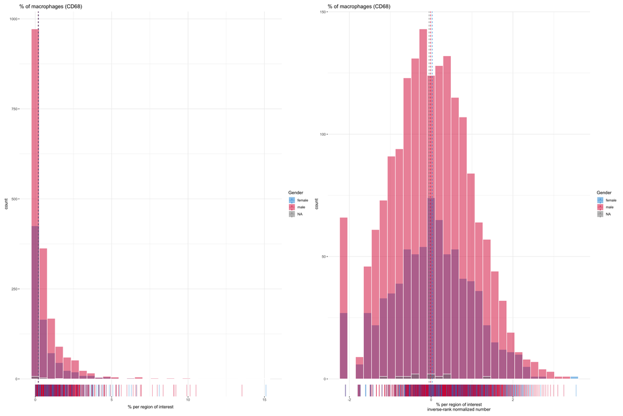

```r
library(labelled)
AEDB$Gender <- to_factor(AEDB$Gender)
library(patchwork)

p1 <- ggpubr::gghistogram(AEDB, "macmean0",
                    # y = "..count..",
                    color = "white",
                    fill = "Gender",
                    palette = c("#1290D9", "#DB003F"),
                    add = "median",
                    #add_density = TRUE,
                    rug = TRUE,
                    #add.params =  list(color = "black", linetype = 2),
                    title = "% of macrophages (CD68)",
                    xlab = "% per region of interest",
                    ggtheme = theme_minimal())
p2 <- ggpubr::gghistogram(AEDB, "MAC_rankNorm",
                    # y = "..count..",
                    color = "white",
                    fill = "Gender",
                    palette = c("#1290D9", "#DB003F"),
                    add = "median",
                    #add_density = TRUE,
                    rug = TRUE,
                    #add.params =  list(color = "black", linetype = 2),
                    title = "% of macrophages (CD68)",
                   xlab = "% per region of interest\ninverse-rank normalized number",
                    ggtheme = theme_minimal())
p1 | p2
```

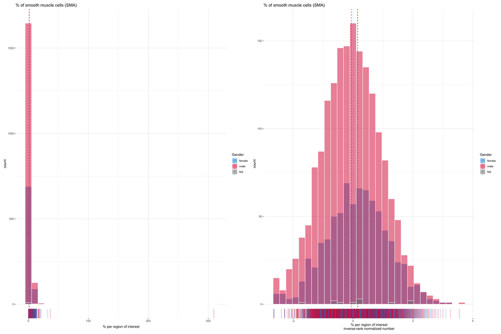

```r
p1 <- ggpubr::gghistogram(AEDB, "smcmean0",
                    # y = "..count..",
                    color = "white",
                    fill = "Gender",
                    palette = c("#1290D9", "#DB003F"),
                    add = "median",
                    #add_density = TRUE,
                    rug = TRUE,
                    #add.params =  list(color = "black", linetype = 2),
                    title = "% of smooth muscle cells (SMA)",
                    xlab = "% per region of interest",
                    ggtheme = theme_minimal())
p2 <- ggpubr::gghistogram(AEDB, "SMC_rankNorm",
                    # y = "..count..",
                    color = "white",
                    fill = "Gender",
                    palette = c("#1290D9", "#DB003F"),
                    add = "median",
                    #add_density = TRUE,
                    rug = TRUE,
                    #add.params =  list(color = "black", linetype = 2),
                    title = "% of smooth muscle cells (SMA)",
                   xlab = "% per region of interest\ninverse-rank normalized number",
                    ggtheme = theme_minimal())
p1 | p2
```

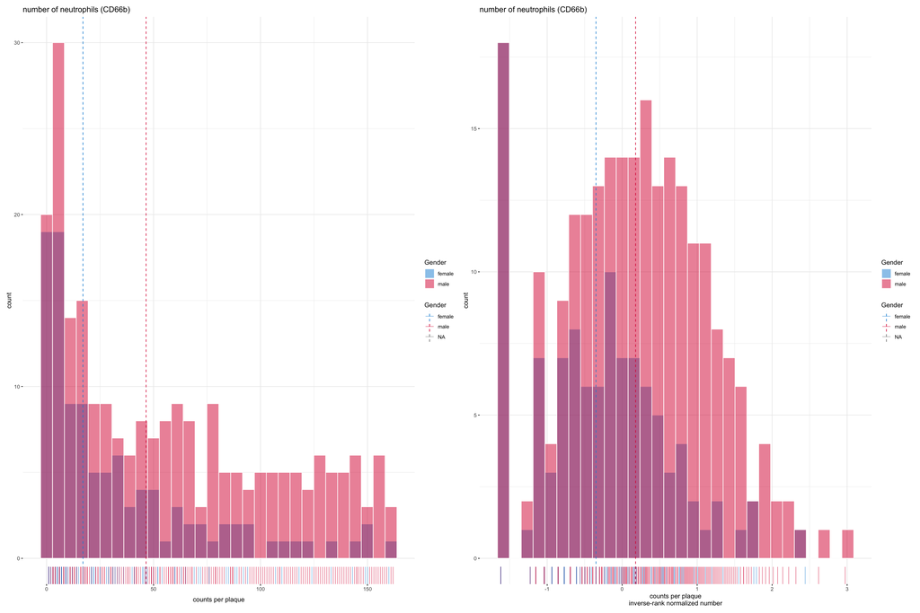

```r
p1 <- ggpubr::gghistogram(AEDB, "neutrophils",
                    # y = "..count..",
                    color = "white",
                    fill = "Gender",
                    palette = c("#1290D9", "#DB003F"),
                    add = "median",
                    #add_density = TRUE,
                    rug = TRUE,
                    #add.params =  list(color = "black", linetype = 2),
                    title = "number of neutrophils (CD66b)",
                    xlab = "counts per plaque",
                    ggtheme = theme_minimal())
p2 <- ggpubr::gghistogram(AEDB, "Neutrophils_rankNorm",
                    # y = "..count..",
                    color = "white",
                    fill = "Gender",
                    palette = c("#1290D9", "#DB003F"),
                    add = "median",
                    #add_density = TRUE,
                    rug = TRUE,
                    #add.params =  list(color = "black", linetype = 2),
                    title = "number of neutrophils (CD66b)",
                   xlab = "counts per plaque\ninverse-rank normalized number",
                    ggtheme = theme_minimal())
p1 | p2
```